# Breast Cancer Survival Analysis with Logit Model

## Overview:

The purpose of this project is to determine how parameters (such as Age, Tumor Size, Survival Months etc.) effect the probabilility of survival from breast cancer. The data that we analysed is explained as follows in souce documentation:

"This dataset of breast cancer patients was obtained from the 2017 November update of the SEER Program of the NCI, which provides information on population-based cancer statistics. The dataset only involved female patients with infiltrating duct and lobular carcinoma breast cancer (SEER primary cites recode NOS histology codes 8522/3) diagnosed in 2006-2010. Patients with unknown tumour size, examined regional LNs, positive regional LNs, and patients whose survival months were less than 1 month were excluded; thus, 4024 patients were ultimately included."

**Source : Kaggle https://www.kaggle.com/datasets/reihanenamdari/breast-cancer

For the analysis we used LOGIT model.

## Dataset Explanation:

- Age : 30 to 69
- Race : Black, White and Others
- Marital Status : Divorced, Married, Widowed, Single
- T Stage : “T” stands for tumor found in the breast itself. The higher the number assigned after it, the bigger or wider the mass.
- N Stage : N describes spread of cancer to nearby lymph nodes
- 6th Stage : Roman numerals I, II, III, or IV. In general, the higher the number, the more advanced the cancer.
- Differantiate : Differentiation refers to how developed the cancer cells are and how well they are organized in the tissue or organ.
- Grade : This is a way to measure how the cells look and how fast they’re growing compared to normal cells. It will also tell them how likely the cancer is to spread to other parts of your body.
  - Grade 1 (well differentiated): The cells look similar to normal breast tissue and are growing slowly.
  - Grade 2 (moderately differentiated): The cells look slightly different from normal cells and are growing slightly faster.
  - Grade 3 (poorly differentiated): The cells look very different from normal cells. They’re growing quickly and are likely to spread.
- A Stage :
  - Regional—Cancer has spread to nearby lymph nodes, tissues, or organs.
  - Distant—Cancer has spread to distant parts of the body
- Tumor Size
- Estrogen Status - Progesterone Status
  - Breast cancer cells have either estrogen (ER) or progesterone (PR) receptors (hormones). Hormone receptor-positive cancers tend to grow more slowly than those that are hormone receptor-negative.
- Reginal Node Examined : Total number of regional lymph nodes that were removed and examined by the pathologist.
- Reginol Node Positive : Total number of nodes that contain metastases.
- Survival Months : 1 to 107 months
- **Status** : Alive or Dead

## Data Filtering Methodology :

The source database does not include a detailed explanation of all columns. We have used the web search to understand the meaning of each column. Some of the columns required domain knowledge of a professional. We considered 8 of the 16 columns for data analysis.

- Age
- Grade : 1,2,3,4
- A Stage : Regional = 1, Distant = 0
- Tumor Size
- Estrogen Status: Positive = 1, Negative = 0
- Progesterone Status: Positive = 1, Negative = 0
- Regional Node Positive/Regional Node Examined : The ratio has been used.
- Survival Months
- Status : This column used as 'outcome'. Patient is alive = 1, dead = 0

## Data Analysis:

```python
import numpy as np
import pandas as pd
from scipy import stats
from scipy import optimize
import statsmodels.api as sm
import matplotlib.pyplot as plt
from numba import jit
import plotly.express as px
%matplotlib inline
```

This is how original dataset looks like:

- We have 4024 rows (patients) and 16 columns (information related to each patient)

```python
df=pd.read_csv('Breast_Cancer.csv', index_col=0)
df.head(10)
```

| id | Age | Race | Marital Status | T Stage | N Stage | 6th Stage | differentiate | Grade | A Stage | Tumor Size | Estrogen Status | Progesterone Status | Regional Node Examined | Reginol Node Positive | Survival Months | Status |
| --- | --- | --- | --- | --- | --- | --- | --- | --- | --- | --- | --- | --- | --- | --- | --- | --- |
| 1 | 68 | White | Married | T1 | N1 | IIA | Poorly differentiated | 3 | Regional | 4 | Positive | Positive | 24 | 1 | 60 | Alive |
| 2 | 50 | White | Married | T2 | N2 | IIIA | Moderately differentiated | 2 | Regional | 35 | Positive | Positive | 14 | 5 | 62 | Alive |
| 3 | 58 | White | Divorced | T3 | N3 | IIIC | Moderately differentiated | 2 | Regional | 63 | Positive | Positive | 14 | 7 | 75 | Alive |
| 4 | 58 | White | Married | T1 | N1 | IIA | Poorly differentiated | 3 | Regional | 18 | Positive | Positive | 2 | 1 | 84 | Alive |
| 5 | 47 | White | Married | T2 | N1 | IIB | Poorly differentiated | 3 | Regional | 41 | Positive | Positive | 3 | 1 | 50 | Alive |
| 6 | 51 | White | Single | T1 | N1 | IIA | Moderately differentiated | 2 | Regional | 20 | Positive | Positive | 18 | 2 | 89 | Alive |
| 7 | 51 | White | Married | T1 | N1 | IIA | Well differentiated | 1 | Regional | 8 | Positive | Positive | 11 | 1 | 54 | Alive |
| 8 | 40 | White | Married | T2 | N1 | IIB | Moderately differentiated | 2 | Regional | 30 | Positive | Positive | 9 | 1 | 14 | Dead |
| 9 | 40 | White | Divorced | T4 | N3 | IIIC | Poorly differentiated | 3 | Regional | 103 | Positive | Positive | 20 | 18 | 70 | Alive |
| 10 | 69 | White | Married | T4 | N3 | IIIC | Well differentiated | 1 | Distant | 32 | Positive | Positive | 21 | 12 | 92 | Alive |

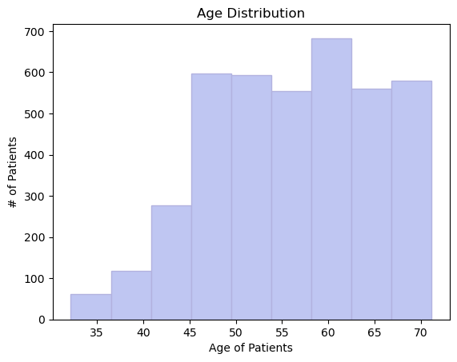

```python
plt.hist(df['Age'], bins=9, align='right', color='#bfc6f2', edgecolor='#B2B2DF')
plt.xlabel('Age of Patients')
plt.ylabel('# of Patients')
plt.title('Age Distribution')
plt.show()
```

- As we can see from the graph above, most of the of the patients are 45+ years old.

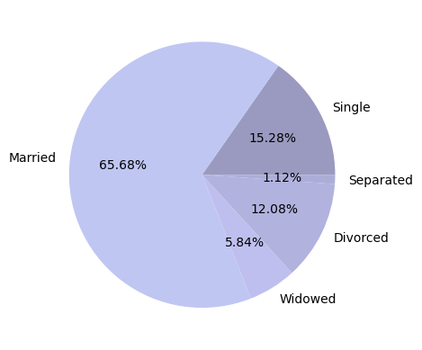

```python
single = df.loc[df['Marital Status']=='Single '].count()[0]
married = df.loc[df['Marital Status']=='Married'].count()[0]
widowed = df.loc[df['Marital Status']=='Widowed'].count()[0]
divorced = df.loc[df['Marital Status']=='Divorced'].count()[0]
seperated = df.loc[df['Marital Status']=='Separated'].count()[0]

labels = ['Single', 'Married','Widowed', 'Divorced','Separated']
colors = ['#9A9AC0', '#bfc6f2', '#BFBFEF', '#B2B2DF','#ADADD8']
plt.pie([single,married,widowed,divorced,seperated], labels=labels, colors = colors, autopct= '%.2f%%')
plt.show()
```

- A vast majority of patients are married, followed by single (15%) and divorced (12%) patients.

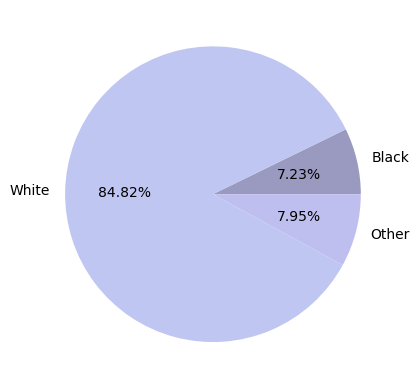

```python
black = df.loc[df['Race']=='Black'].count()[0]
white = df.loc[df['Race']=='White'].count()[0]
others = df.loc[df['Race']=='Other'].count()[0]

labels = ['Black', 'White','Other']
colors = ['#9A9AC0', '#bfc6f2', '#BFBFEF']
plt.pie([black, white, others], labels=labels, colors = colors, autopct= '%.2f%%')
plt.show()
```

- And the patients we are going to analyse are predominantly White.

Before analysing the data, we need to re-assign / change some of the values :

```python
df['Status'] = np.where(df['Status'] == 'Alive', 1 , 0)
df['A Stage'] = np.where(df['A Stage'] == 'Regional', 1 , 0)
df['Estrogen Status'] = np.where(df['Estrogen Status'] == 'Positive', 1 , 0)
df['Progesterone Status'] = np.where(df['Progesterone Status'] == 'Positive', 1 , 0)
df.loc[(df['Grade']==' anaplastic; Grade IV'), 'Grade']= 4 # I've replaced the string 'anaplastic grade IV'  with integer 4.
df['RN_ratio'] = df['Reginol Node Positive']/df['Regional Node Examined']
df.head()
```

| id | Age | Race | Marital Status | T Stage | N Stage | 6th Stage | differentiate | Grade | A Stage | Tumor Size | Estrogen Status | Progesterone Status | Regional Node Examined | Reginol Node Positive | Survival Months | Status | RN_ratio |
| --- | --- | --- | --- | --- | --- | --- | --- | --- | --- | --- | --- | --- | --- | --- | --- | --- | --- |
| 1 | 68 | White | Married | T1 | N1 | IIA | Poorly differentiated | 3 | 1 | 4 | 1 | 1 | 24 | 1 | 60 | 1 | 0.041667 |
| 2 | 50 | White | Married | T2 | N2 | IIIA | Moderately differentiated | 2 | 1 | 35 | 1 | 1 | 14 | 5 | 62 | 1 | 0.357143 |
| 3 | 58 | White | Divorced | T3 | N3 | IIIC | Moderately differentiated | 2 | 1 | 63 | 1 | 1 | 14 | 7 | 75 | 1 | 0.500000 |
| 4 | 58 | White | Married | T1 | N1 | IIA | Poorly differentiated | 3 | 1 | 18 | 1 | 1 | 2 | 1 | 84 | 1 | 0.500000 |
| 5 | 47 | White | Married | T2 | N1 | IIB | Poorly differentiated | 3 | 1 | 41 | 1 | 1 | 3 | 1 | 50 | 1 | 0.333333 |

- We need to standartize the 'Age', 'Tumor Size', 'Survival Months', and 'Grade' columns. And also adding intercept (1's) to the frame.

```python
def standardize_numeric_features(df, column):

    var_mean = df[column].mean()
    var_std = df[column].std()
    df[column] = round((df[column] - var_mean) / var_std, 6)
    return df[column]

df['Age']=standardize_numeric_features(df, 'Age')
df['Tumor Size']=standardize_numeric_features(df, 'Tumor Size')
df['Survival Months']=standardize_numeric_features(df, 'Survival Months')
df['Grade'] = df['Grade'].astype(str).astype(int) # converted Grade column to integer
df['Grade']=standardize_numeric_features(df, 'Grade')
df['intercept'] = 1

df.head()
```

| id | Age | Race | Marital Status | T Stage | N Stage | 6th Stage | differentiate | Grade | A Stage | Tumor Size | Estrogen Status | Progesterone Status | Regional Node Examined | Reginol Node Positive | Survival Months | Status | RN_ratio | intercept |
| --- | --- | --- | --- | --- | --- | --- | --- | --- | --- | --- | --- | --- | --- | --- | --- | --- | --- | --- |
| 1 | 1.565059 | White | Married | T1 | N1 | IIA | Poorly differentiated | 1.330866 | 1 | -1.253506 | 1 | 1 | 24 | 1 | -0.492900 | 1 | 0.041667 | 1 |
| 2 | -0.443167 | White | Married | T2 | N2 | IIIA | Moderately differentiated | -0.235958 | 1 | 0.214319 | 1 | 1 | 14 | 5 | -0.405645 | 1 | 0.357143 | 1 |
| 3 | 0.449378 | White | Divorced | T3 | N3 | IIIC | Moderately differentiated | -0.235958 | 1 | 1.540095 | 1 | 1 | 14 | 7 | 0.161510 | 1 | 0.500000 | 1 |
| 4 | 0.449378 | White | Married | T1 | N1 | IIA | Poorly differentiated | 1.330866 | 1 | -0.590617 | 1 | 1 | 2 | 1 | 0.554156 | 1 | 0.500000 | 1 |
| 5 | -0.777872 | White | Married | T2 | N1 | IIB | Poorly differentiated | 1.330866 | 1 | 0.498414 | 1 | 1 | 3 | 1 | -0.929173 | 1 | 0.333333 | 1 |

- Choosing the columns that we are going to use for analysis:

```python
df_logit=df[[ 'intercept','Age', 'RN_ratio','A Stage','Tumor Size', 'Grade', 'Estrogen Status', 'Progesterone Status','Survival Months', 'Status']]
df_logit.head()
```

| id | intercept | Age | RN_ratio | A Stage | Tumor Size | Grade | Estrogen Status | Progesterone Status | Survival Months | Status |
| --- | --- | --- | --- | --- | --- | --- | --- | --- | --- | --- |
| 1 | 1 | 1.565059 | 0.041667 | 1 | -1.253506 | 1.330866 | 1 | 1 | -0.492900 | 1 |
| 2 | 1 | -0.443167 | 0.357143 | 1 | 0.214319 | -0.235958 | 1 | 1 | -0.405645 | 1 |
| 3 | 1 | 0.449378 | 0.500000 | 1 | 1.540095 | -0.235958 | 1 | 1 | 0.161510 | 1 |
| 4 | 1 | 0.449378 | 0.500000 | 1 | -0.590617 | 1.330866 | 1 | 1 | 0.554156 | 1 |
| 5 | 1 | -0.777872 | 0.333333 | 1 | 0.498414 | 1.330866 | 1 | 1 | -0.929173 | 1 |

- And converting it to numpy array:

```python
df_logit=np.array(df_logit)
```

```python
def sigmoid_mn(data, beta):
    Xb = np.dot(data, beta)
    eXb = np.exp(Xb)
    eXb = eXb /eXb.sum(1)[:, None]
    return eXb

def LL_mn(params, *args):
    y, X, n_params, n_classes = args[0], args[1], args[2], args[3]
    beta = params
    beta = np.array(beta).reshape(n_params, -1, order='F')
    beta[:,0] = [0]*n_params
    d = pd.get_dummies(y).to_numpy()
    probs = sigmoid_mn(X, beta)
    logged = np.log(probs)
    ll = d * logged
    return -np.sum(ll)

n_params = 9
n_classes = 2
start_values = np.random.rand(n_params*n_classes)


res = optimize.minimize(LL_mn, x0 =start_values, args =(df_logit[:, -1], df_logit[:, :-1], n_params, n_classes))
res['x']
```

```
array([ 0.56986338,  0.31129297,  0.658479  ,  0.59175395,  0.91384652,
        0.3783107 ,  0.97574347,  0.24264804,  0.75242856,  1.90164097,
       -0.25456017, -1.66084955,  0.33578485, -0.17057304, -0.36190193,
        0.39926157,  0.51332114,  1.40272828])
```

- We would like to check our results with Python's Logit function:

```python
log_reg = sm.Logit(df_logit[:, -1], df_logit[:, :-1]).fit()
log_reg.summary()
```

```
Optimization terminated successfully.
         Current function value: 0.284295
         Iterations 7
```

Logit Regression Results

| Dep. Variable: | y | No. Observations: | 4024 |
| --- | --- | --- | --- |
| Model: | Logit | Df Residuals: | 4015 |
| Method: | MLE | Df Model: | 8 |
| Date: | Sun, 18 Dec 2022 | Pseudo R-squ.: | 0.3358 |
| Time: | 18:45:30 | Log-Likelihood: | -1144.0 |
| converged: | True | LL-Null: | -1722.3 |
| Covariance Type: | nonrobust | LLR p-value: | 2.197e-244 |

|  | coef | std err | z | P>\|z\| | [0.025 | 0.975] |
| --- | --- | --- | --- | --- | --- | --- |
| const | 1.9016 | 0.358 | 5.315 | 0.000 | 1.200 | 2.603 |
| x1 | -0.2546 | 0.055 | -4.602 | 0.000 | -0.363 | -0.146 |
| x2 | -1.6608 | 0.179 | -9.295 | 0.000 | -2.011 | -1.311 |
| x3 | 0.3358 | 0.295 | 1.139 | 0.255 | -0.242 | 0.913 |
| x4 | -0.1706 | 0.051 | -3.366 | 0.001 | -0.270 | -0.071 |
| x5 | -0.3619 | 0.058 | -6.220 | 0.000 | -0.476 | -0.248 |
| x6 | 0.3993 | 0.222 | 1.800 | 0.072 | -0.035 | 0.834 |
| x7 | 0.5133 | 0.150 | 3.418 | 0.001 | 0.219 | 0.808 |
| x8 | 1.4027 | 0.062 | 22.566 | 0.000 | 1.281 | 1.525 |

- To interpret our results, we need to describe the marginal effects of each independant variables:

```python
log_reg.get_margeff(at='mean').summary()
```

Logit Marginal Effects

| Dep. Variable: | y |
| --- | --- |
| Method: | dydx |
| At: | mean |

|  | dy/dx | std err | z | P>\|z\| | [0.025 | 0.975] |
| --- | --- | --- | --- | --- | --- | --- |
| x1 | -0.0181 | 0.004 | -4.617 | 0.000 | -0.026 | -0.010 |
| x2 | -0.1180 | 0.013 | -9.015 | 0.000 | -0.144 | -0.092 |
| x3 | 0.0239 | 0.021 | 1.138 | 0.255 | -0.017 | 0.065 |
| x4 | -0.0121 | 0.004 | -3.363 | 0.001 | -0.019 | -0.005 |
| x5 | -0.0257 | 0.004 | -6.241 | 0.000 | -0.034 | -0.018 |
| x6 | 0.0284 | 0.016 | 1.786 | 0.074 | -0.003 | 0.059 |
| x7 | 0.0365 | 0.011 | 3.393 | 0.001 | 0.015 | 0.058 |
| x8 | 0.0996 | 0.005 | 19.908 | 0.000 | 0.090 | 0.109 |

- x1 : Age

A unit increase in "Age", decrease the probability of survival in breast cancer by 1.81 %. This is in parallel with Ref (1) below.

- x2 : RN_Ratio (Regional Node Examined)

This parameter represents the ratio of examined regional nodes. As pathologist find more 'positive' value in the examination sample, the ratio will be higher. This is in parallel with Ref (2) below.

A unit increase in "Regional Node Examination", decrease the probability of survival by 11.8%.

- x3 : A Stage

(3) A Stage is a way of describing how extensive the breast cancer is. So in our analysis, regional was equal to 1, and distant was 0 which means the cancer spreads distant parts of the body beyond the breast. This is in parallel with Ref (3) below.

A unit increase in "A Stage", increase the probability of survival by 2.39%

- x4 : Tumor Size

According to Ref (4), "Tumor size is related to prognosis (chances for survival) and is part of breast cancer staging. In most cases, the smaller the tumor, the better the prognosis tends to be". So:

A unit increase in "Tumor Size", decrease the probability of survival by 1.21%

- x5 : Grade

According to Ref (5), breast cancers are given a grade of 1, 2 or 3 according to how different the cancer cells are to normal breast cells and how quickly they are growing.

A unit increase in "Grade", decrease the probability of survival by 2.57%

- x6 and x7 : Estrogen Status / Progesterone Status

According to Ref (6), women with high levels of both the oestrogen and progesterone receptors have the best chance of surviving – they respond better to treatment, and their cancer is less likely to spread.

A unit increase in "Estrogen Status", increase the probability of survival by 2.84% and a unit increase in "Progesterone Status", increase the probability of survival by 3.65%.

- x8 : Survival Months

A unit increase in "Survival Months", increase the probability of survival by 9.96%

## Resources

- 1 : https://www.ncbi.nlm.nih.gov/pmc/articles/PMC5087840/
- 2 : https://news.cancerresearchuk.org/2015/07/08/solving-a-breast-cancer-mystery-why-do-double-positive-women-do-better/
- 3 : https://www.cancer.net/cancer-types/breast-cancer/stages#:~:text=Staging%20is%20a%20way%20of,after%20a%20patient%20undergoes%20surgery.
- 4 : https://cancer.ca/en/cancer-information/cancer-types/breast/prognosis-and-survival
- 5 : https://www.cancer.org/cancer/breast-cancer/understanding-a-breast-cancer-diagnosis/breast-cancer-grades.html#:~:text=A%20low%20grade%20number%20(grade,than%20a%20grade%203%20cancer.
- 6 : https://news.cancerresearchuk.org/2015/07/08/solving-a-breast-cancer-mystery-why-do-double-positive-women-do-better/

Other readings used for understanding the database:

- (https://www.cdc.gov/cancer/breast/basic_info/risk_factors.htm)
- (https://www.webmd.com/breast-cancer/stages-grades-breast-cancer)
- https://www.mskcc.org/cancer-care/types/breast/diagnosis/stages-breast
- https://www.frontiersin.org/articles/10.3389/fonc.2021.585613/full